#### Практическая работа №4

### Метод наименьших квадратов в задаче линейной и нелинейной регрессии

> Глушков Егор Александрович, гр. 20.М04-мм  
> Вариант 4
1. Промоделировать нелинейную модель $y = f(x, a, b) + \delta$ с несмещённой нормально распределенной ошибкой, дисперсия которой равна $\varepsilon$, считая, $x$ стандартно нормально распределённой случайной величиной.
- $f(x, a, b) = a \sin x + bx^2, \; a=2, b=1, \varepsilon=0.8$
2. Оценить параметры нелинейной модели по методу наименьших квадратов (численно). Применить к модельным данным линейную модель и оценить параметры. Построить на двумерной диаграмме основную и линейную модель. Сравнить невязки для обеих моделей.
3. Для линейной модели выполнить дисперсионный анализ, проверить значимость прогноза и коэффициентов регрессии. Сравнить непосредственные вычисления с результатами встроенной функции.
4. Промоделировать данные для множественной регрессии. Применить функцию $lm$. Ответить на вопросы о значимости коэффициента детерминации, частных коэффициентов регрессии, о коэффициенте корреляции между остатком и независимыми переменными.

> Задание линейной и нелинейной моделей регрессии

Нелинейная модель
$$y_i = a \sin x_i + bx_i^2 + \delta_i, \quad \delta_i \sim \mathcal{N}(0, \sigma)$$
Модель одномерной линейной регрессии

$$y_i = \alpha + \beta x_i, \quad \delta_i \sim \mathcal{N}(0, \sigma)$$

Задаем нелинейную и линейную модели и их функции ошибки *L*

```r
N <- 100
f <- function(x, ab) ab[1] * sin(x) + ab[2] * x^2
L <- function(X, Y, ab) sum((Y - f(X, ab))^2)

f_lin <- function(x, ab_lin) ab_lin[1] + ab_lin[2] * x
L_lin <- function(X, Y, ab_lin) sum((Y - f_lin(X, ab_lin))^2)
```

Моделируем данные нелинейной модели

```r
ab <- c(2, 1)
eps <- 0.8

X <- rnorm(N)
Y <- f(X, ab) + rnorm(N, 0, eps^2)
```

> Оценка параметров линейной модели и наилучший прогноз

$$\hat{\beta} = \frac{\sum\nolimits_i x_i y_i - n \bar{x} \bar{y}}{{\sum\nolimits_i x_i^2 - n \bar{x}^2}}, \quad \hat{\alpha} = \bar{y} - \hat{\beta} \bar{x}, \quad \hat{y_i} = \hat{\alpha} - \hat{\beta} x_i$$

```r
b. <- (sum(X * Y) - N * mean(X) * mean(Y)) / (sum(X * X) - N * mean(X)^2)
a. <- mean(Y) - b. * mean(X)
ab_lin_est <- c(a., b.)
Y. <- f_lin(X, ab_lin_est)
ab_lin_est
```

```
[1] 0.9219083 1.2337556
```

> Дисперсионный анализ

Источники вариации: общий $Q_T$, обусловленный регрессией $Q_R$, невязка $Q_E$. Коэффициент детерминации $R^2$

```r
QT <- sum((Y - mean(Y))^2)
QR <- sum((Y. - mean(Y))^2)
QE <- sum((Y - Y.)^2)
R2 <- QR / QT

c(QT=QT, QR=QR, QE=QE, R2=R2)
```

```
         QT          QR          QE          R2
348.7500256 135.4274537 213.3225718   0.3883224
```

38.8% дисперсии объясняется данной моделью – линией регресии.  
Проверим равенство источников вариации [посчитаны верно]:

```r
print(paste("(QR + QE == QT):", QR + QE - QT < 1e-9))
```

```
[1] "(QR + QE == QT): TRUE"
```

Дисперсии общая и коэффициентов регрессии

```r
xx <- sum((X - mean(X))^2)
S2 <- QE / (N - 2)
S2.a <- S2 * sum(X^2) / (xx * N)
S2.b <- S2 / xx

c(S2, S2.a, S2.b)
```

```
[1] 2.17676094 0.02176906 0.02446596
```

Статистики для проверки значимости прогноза и коэффициентов регрессии

```r
F_stat <- QR / QE * (N - 2)

Pf <- 1 - pf(F_stat, 1, N - 2)
T.a <- ab_lin_est[1] / sqrt(S2.a)
T.b <- ab_lin_est[2] / sqrt(S2.b)

P.a <- 2*(1 - pt(abs(T.a), N - 2))
P.b <- 2*(1 - pt(abs(T.b), N - 2))

P.model <- 1 - pf(F_stat, 1, N - 2)
```

Выведем самостоятельно посчитанные величины:

```r
show_stats_coef <- rbind(c(ab_lin_est[1], sqrt(S2.a), T.a, P.a), c(ab_lin_est[2], sqrt(S2.b), T.b, P.b))
colnames(show_stats_coef) <- c("Estimate", "Std.Error","t value", "Pr(>|t|)")
rownames(show_stats_coef) <- c("(Intercept)", "X"); show_stats_coef
```

```
             Estimate Std.Error  t value     Pr(>|t|)
(Intercept) 0.9219083 0.1475434 6.248386 1.075902e-08
X           1.2337556 0.1564160 7.887656 4.401812e-12
```

```r
show_stats_model <- c(sd=sqrt(S2), R2=R2, F_stats=F_stat, p.value.F=P.model); show_stats_model
```

```
          sd           R2      F_stats    p.value.F
1.475385e+00 3.883224e-01 6.221512e+01 4.401812e-12
```

Проверим при помощи встроенной функции *lm*:

```r
summary(lm(Y~X))
```

```
Call:
lm(formula = Y ~ X)

Residuals:
    Min      1Q  Median      3Q     Max
-2.1924 -0.8860 -0.3422  0.5329  6.1879

Coefficients:
            Estimate Std. Error t value Pr(>|t|)
(Intercept)   0.9219     0.1475   6.248 1.08e-08 ***
X             1.2338     0.1564   7.888 4.40e-12 ***
---
Signif. codes:  0 ‘***’ 0.001 ‘**’ 0.01 ‘*’ 0.05 ‘.’ 0.1 ‘ ’ 1

Residual standard error: 1.475 on 98 degrees of freedom
Multiple R-squared:  0.3883,    Adjusted R-squared:  0.3821
F-statistic: 62.22 on 1 and 98 DF,  p-value: 4.402e-12
```

Как видно, все посчитанные величины совпадают. Вычисления были верны. Что касается самой модели, то итоговое *p-value* (близкое к нулю) говорит о значимости регрессии, также малые *Pr* говорят о том, что соответствующие этим уровням значимости коэффициенты отличны от нуля и вносят вклад в модель. $R^2$ сообщает, что 38.8% дисперсии объясняется данной моделью – линией регресии.

> Оценка параметров нелинейной модели по МНК

Параметры нелинейной модели оцениваем методом наименьших квадратов (МНК)

```r
NLM <- nlm(function(ab) L(X, Y, ab), ab)
ab. <- NLM$estimate
rbind(ab=ab, ab.=ab.)
```

```
        [,1]      [,2]
ab  2.000000 1.0000000
ab. 1.864256 0.9972268
```

```r
plot(X, Y)
f_ <- function(x) f(x, ab); curve(f_, -3, 3, add=TRUE, col=2)
```

```r
f_ <- function(x) f(x, ab.); curve(f_, -3, 3, add=TRUE, col=3)
f_ <- function(x) f_lin(x, ab_lin_est); curve(f_, -3, 3, add=TRUE, col=4, lty=2)
```

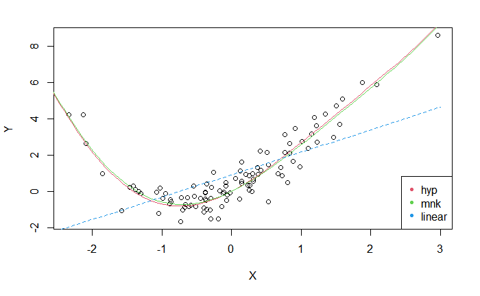

```r
legend('bottomright', c('hyp', 'mnk', 'linear'), pch=20, col=2:4)
```

Невязки

```r
c(Q.linear=L_lin(X, Y, ab_lin_est), Q.hyp=L(X, Y, ab), Q.mnk=L(X, Y, ab.))
```

```
 Q.linear     Q.hyp     Q.mnk
213.32257  42.52355  41.80144
```

Заметим, что линейная модель оценивает достаточно грубо, тогда как нелинейная модель достаточно точно описывает данные. Конечно, меньшей невязкой как суммы квадратов отклонений точек от графика обладает модель, построенная по МНК.

> Множественная регрессия

```r
N <- 100
a <- c(2, -1, 5)
eps <- 3
X1 <- rnorm(N, 1, 1.5)
X2 <- rnorm(N, 2, 0.5)
Y <- a[1] * X1 + a[2] * X2 + a[3] + rnorm(N, 0, eps^2)

SLM <- summary(lm(Y ~ X1 + X2)); SLM
```

```
Call:
lm(formula = Y ~ X1 + X2)

Residuals:
     Min       1Q   Median       3Q      Max
-16.1076  -6.0017  -0.6972   4.7822  21.5682

Coefficients:
            Estimate Std. Error t value Pr(>|t|)
(Intercept)   6.9812     3.3939   2.057  0.04237 *
X1            1.5445     0.5706   2.707  0.00802 **
X2           -1.3288     1.6065  -0.827  0.41018
---
Signif. codes:  0 ‘***’ 0.001 ‘**’ 0.01 ‘*’ 0.05 ‘.’ 0.1 ‘ ’ 1

Residual standard error: 8.294 on 97 degrees of freedom
Multiple R-squared:  0.08022,   Adjusted R-squared:  0.06125
F-statistic:  4.23 on 2 and 97 DF,  p-value: 0.01733
```

Согласно *p-value* < 0.05 отвергаем гипотезу о том, что данная модель не зависит от предикторов (т.е. их коэффициенты равны нулю – отвергаем). Отвергается и незначимость коэффициента при *X1*, а вот *X2*, как следует, не вносит весомый вклад ($p.value = 0.41 > 0.05$, то не отвергается факт, коэффициент незначим)

Проверим некоррелированность остатков [практически равны 0]

```r
c(cor(X1, SLM$residuals), cor(X1, SLM$residuals))
```

```
[1] -5.386815e-17 -5.386815e-17
```

```r
op <- par(mfrow = c(2, 2))

plot(X1, SLM$residuals)
title(sub=paste("r", round(cor(SLM$residuals, X1), 3), sep="="))
```

```r
plot(X2, SLM$residuals)
title(sub=paste("r", round(cor(SLM$residuals, X2), 3), sep="="))
```

```r
plot(X1, Y)
title(sub=paste("r", round(cor(X1, Y),3), sep="="))
```

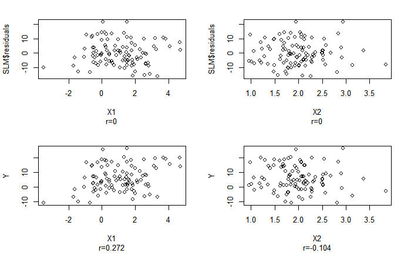

```r
plot(X2, Y)
title(sub=paste("r", round(cor(X2, Y), 3), sep="="))
```

Как видно на верхних двух рисунках, коэффициент корреляции остатков с независимыми переменными равен нулю, тогда как в целом некоторая зависимость (линейная) в данных наблюдается (см. нижние рисунки).

```r
sh_t <- shapiro.test(SLM$residuals); sh_t
```

```
    Shapiro-Wilk normality test

data:  SLM$residuals
W = 0.97998, p-value = 0.1325
```

Согласно критерию Шапиро-Уилка, нормальность остатков не отвергается с $p.value = 0.133$

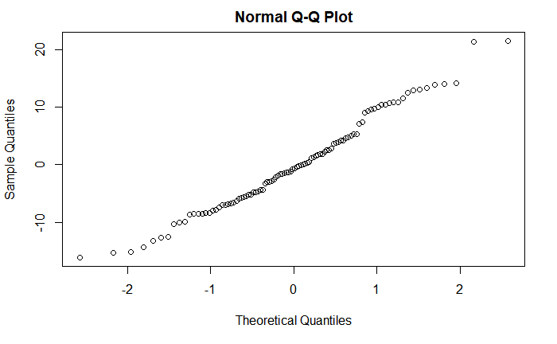

```r
qqnorm(SLM$residuals)
```